# EkonometriaElizaTworkowska

Eliza Tworkowska

2025-05-30

# O projekcie

W projekcie będziemy przewidywać dane ciśnienia krwii na podstawie zanonimizowanych wskaźników zdrowia i stylu zycia pacjentów. Do wszystkich modeli samodzielnie dobiorę zmienne na podstawie tabeli korelacji i wykresów zależnośći.

# Wczytanie danych

Dane wczytujemy w formie CSV, więc wczytujemy naszą tabelę za pomocą read.csv. Składa się ona z 9 kolumn:

1. **systolic** - Ciśnienie skurczowe, zmienna którą będziemy objaśniać.
2. **weight** - Waga pacjenta
3. **height** - Wzrost pacjenta
4. **BMI** - Wskaźnik masy ciała (masa (kg) / wysokość (m))
5. **waist** - Obwód w talii ciała pacjenta
6. **age** - Wiek pacjenta
7. **diabetes** - Czy pacjent ma cukrzycę (zmienna binarna, 1 oznacza tak; 0 - nie)
8. **smoker** - Czy pacjent pali papierosy (zmienna binarna, 1 oznacza tak; 0 - nie)
9. **fastfood** - Częstotliwość w ciągu tygodnia jedzenia “fastfoodów”, nie zdrowego jedzenia

Wczytamy dane, a następnie wyświetlimy krótkie przedstawienie struktury za pomocą funkcji head.

```r
health <- read_csv("health.csv")
head(health)
```

| systolic | weight | height | bmi | waist | age | diabetes | smoker | fastfood |
| --- | --- | --- | --- | --- | --- | --- | --- | --- |
| 100 | 98.6 | 172.0 | 33.3 | 120.4 | 43 | 0 | 1 | 5 |
| 112 | 96.9 | 186.0 | 28.0 | 107.8 | 57 | 0 | 0 | 0 |
| 134 | 108.2 | 154.4 | 45.4 | 120.3 | 38 | 0 | 1 | 2 |
| 108 | 84.8 | 168.9 | 29.7 | 109.0 | 75 | 0 | 0 | 1 |
| 128 | 97.0 | 175.3 | 31.6 | 111.1 | 42 | 0 | 1 | 1 |
| 102 | 102.4 | 150.5 | 45.2 | 130.7 | 63 | 1 | 0 | 3 |

| systolic <dbl> | weight <dbl> | height <dbl> | bmi <dbl> | waist <dbl> | age <dbl> | diabetes <dbl> | smoker <dbl> | fastfood <dbl> |
| --- | --- | --- | --- | --- | --- | --- | --- | --- |
| 100 | 98.6 | 172.0 | 33.3 | 120.4 | 43 | 0 | 1 | 5 |
| 112 | 96.9 | 186.0 | 28.0 | 107.8 | 57 | 0 | 0 | 0 |
| 134 | 108.2 | 154.4 | 45.4 | 120.3 | 38 | 0 | 1 | 2 |
| 108 | 84.8 | 168.9 | 29.7 | 109.0 | 75 | 0 | 0 | 1 |
| 128 | 97.0 | 175.3 | 31.6 | 111.1 | 42 | 0 | 1 | 1 |
| 102 | 102.4 | 150.5 | 45.2 | 130.7 | 63 | 1 | 0 | 3 |

6 rows

## Analiza statystyczna

```r
library(psych)
describe(health)
```

|  | vars | n | mean | sd | median | trimmed | mad | min | max | range | skew | kurtosis | se |
| --- | --- | --- | --- | --- | --- | --- | --- | --- | --- | --- | --- | --- | --- |
| systolic | 1 | 1475 | 124.7294915 | 17.6205880 | 122.0 | 123.39542760 | 14.82600 | 80.0 | 224.0 | 144.0 | 0.92410433 | 1.7935138 | 0.458801032 |
| weight | 2 | 1475 | 83.5631864 | 20.5823008 | 81.0 | 81.93564776 | 18.82902 | 29.1 | 203.5 | 174.4 | 1.02958266 | 2.2043313 | 0.535917466 |
| height | 3 | 1475 | 170.1799322 | 9.3263296 | 170.3 | 170.27019475 | 9.63690 | 141.2 | 200.4 | 59.2 | -0.08185988 | -0.2706158 | 0.242836940 |
| bmi | 4 | 1475 | 28.7939661 | 6.4705510 | 27.9 | 28.19017782 | 5.93040 | 13.4 | 62.0 | 48.6 | 1.03564542 | 1.6705876 | 0.168478797 |
| waist | 5 | 1475 | 100.0345085 | 16.1536628 | 98.9 | 99.13937341 | 15.71556 | 56.2 | 176.0 | 119.8 | 0.58740508 | 0.5767905 | 0.420605555 |
| age | 6 | 1475 | 48.8867797 | 16.9753211 | 49.0 | 48.48602879 | 20.75640 | 20.0 | 80.0 | 60.0 | 0.13877004 | -1.0384093 | 0.441999715 |
| diabetes | 7 | 1475 | 0.1423729 | 0.3495507 | 0.0 | 0.05334462 | 0.00000 | 0.0 | 1.0 | 1.0 | 2.04482311 | 2.1827828 | 0.009101525 |
| smoker | 8 | 1475 | 0.4779661 | 0.4996837 | 0.0 | 0.47248095 | 0.00000 | 0.0 | 1.0 | 1.0 | 0.08813160 | -1.9935830 | 0.013010655 |
| fastfood | 9 | 1475 | 2.1396610 | 2.8726037 | 1.0 | 1.57493649 | 1.48260 | 0.0 | 22.0 | 22.0 | 2.77594754 | 10.7061000 | 0.074796229 |

|  | vars <int> | n <dbl> | mean <dbl> | sd <dbl> | median <dbl> | trimmed <dbl> | mad <dbl> | min <dbl> | max <dbl> |  |
| --- | --- | --- | --- | --- | --- | --- | --- | --- | --- | --- |
| systolic | 1 | 1475 | 124.7294915 | 17.6205880 | 122.0 | 123.39542760 | 14.82600 | 80.0 | 224.0 |  |
| weight | 2 | 1475 | 83.5631864 | 20.5823008 | 81.0 | 81.93564776 | 18.82902 | 29.1 | 203.5 |  |
| height | 3 | 1475 | 170.1799322 | 9.3263296 | 170.3 | 170.27019475 | 9.63690 | 141.2 | 200.4 |  |
| bmi | 4 | 1475 | 28.7939661 | 6.4705510 | 27.9 | 28.19017782 | 5.93040 | 13.4 | 62.0 |  |
| waist | 5 | 1475 | 100.0345085 | 16.1536628 | 98.9 | 99.13937341 | 15.71556 | 56.2 | 176.0 |  |
| age | 6 | 1475 | 48.8867797 | 16.9753211 | 49.0 | 48.48602879 | 20.75640 | 20.0 | 80.0 |  |
| diabetes | 7 | 1475 | 0.1423729 | 0.3495507 | 0.0 | 0.05334462 | 0.00000 | 0.0 | 1.0 |  |
| smoker | 8 | 1475 | 0.4779661 | 0.4996837 | 0.0 | 0.47248095 | 0.00000 | 0.0 | 1.0 |  |
| fastfood | 9 | 1475 | 2.1396610 | 2.8726037 | 1.0 | 1.57493649 | 1.48260 | 0.0 | 22.0 |  |

9 rows | 1-10 of 14 columns

Dzięki analizie statystycznej widzimy najważniejsze informacje na temat każdej zmiennej. Z uwagi na to, że będziemy skupiać się na zmiennej ciśnienia krwi skupmy się na jej danych.

Przede wszystkim mamy 1475 obserwacji. Średnie (mean) ciśnienie wynosi ~124.73, odchylenie standardowe: 17.62, mediana: 122. Najmniejsze ciśnienie wynosi 80 a największe 224. To bardzo duży rozrzut (range: 144) w porównaniu z naszą średnią, co może wpłynąć na późniejsze problemu w próbie modelowania tej zmiennej.

Kolejne ciekawe informacje z naszej analizy statystycznej: - 47.80% pacjentów pali papierosy - średnio jedzą 2 razy w tygodniu fast food - Średni wiek wynosi 48 lat - Średnio próbka badawcza ma nadwagę (BMI=28)

## Histogram

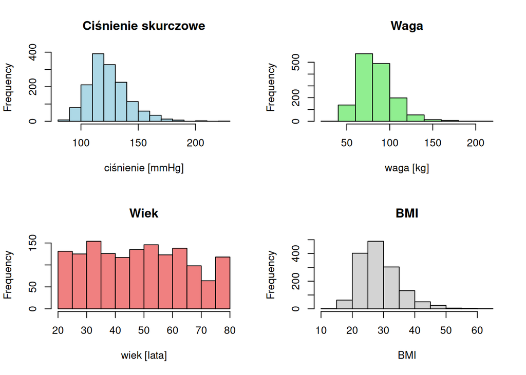

```r
par(mfrow = c(2, 2))
hist(health$systolic, main="Ciśnienie skurczowe", xlab="ciśnienie [mmHg]", col="lightblue")
hist(health$weight, main="Waga", xlab="waga [kg]", col="lightgreen")
hist(health$age, main="Wiek", xlab="wiek [lata]", col="lightcoral")
hist(health$bmi, main="BMI", xlab="BMI", col="lightgray")
```

# Badanie korelacji zmiennych

## Macierz korelacji

```r
# Obliczenie macierzy korelacji
library(dplyr)
M <- cor(select(health, systolic,weight,age,bmi,smoker,diabetes,fastfood,waist,height), use = "complete.obs")
```

Otrzymaną macierz korelacji można zwizualizować przy użyciu pakietu corrplot:

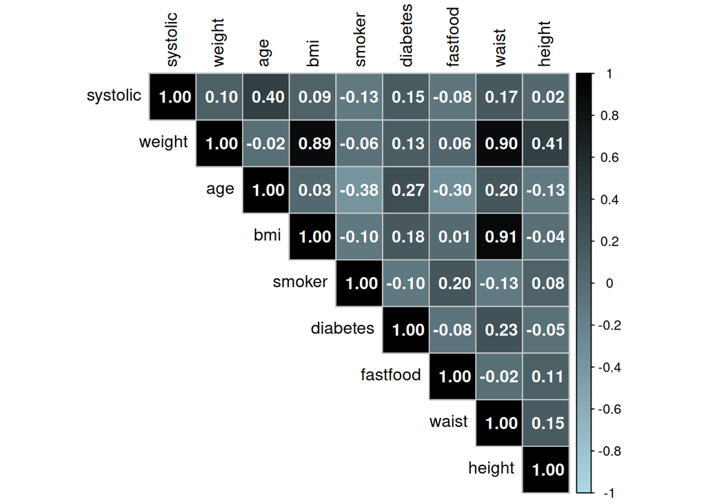

```r
library(corrplot)
library(dplyr)
# Obliczenie macierzy korelacji
M <- cor(select(health, systolic, weight, age, bmi, smoker, diabetes, fastfood, waist, height),
         use = "complete.obs")

corrplot(M,
         method = "color",
         type = "upper",
         tl.col = "black",
         addCoef.col = "white",
         col = colorRampPalette(c("lightblue", "black"))(100),
         bg = "gray95",  # Kolor tła wykresu
         addgrid.col = "gray80")  # Kolor siatki
```

```r
round(M,2)
```

```
##          systolic weight   age   bmi smoker diabetes fastfood waist height
## systolic     1.00   0.10  0.40  0.09  -0.13     0.15    -0.08  0.17   0.02
## weight       0.10   1.00 -0.02  0.89  -0.06     0.13     0.06  0.90   0.41
## age          0.40  -0.02  1.00  0.03  -0.38     0.27    -0.30  0.20  -0.13
## bmi          0.09   0.89  0.03  1.00  -0.10     0.18     0.01  0.91  -0.04
## smoker      -0.13  -0.06 -0.38 -0.10   1.00    -0.10     0.20 -0.13   0.08
## diabetes     0.15   0.13  0.27  0.18  -0.10     1.00    -0.08  0.23  -0.05
## fastfood    -0.08   0.06 -0.30  0.01   0.20    -0.08     1.00 -0.02   0.11
## waist        0.17   0.90  0.20  0.91  -0.13     0.23    -0.02  1.00   0.15
## height       0.02   0.41 -0.13 -0.04   0.08    -0.05     0.11  0.15   1.00
```

Z macierzy korelacji możemy wyciągnąć następujące wnioski:

**1. Zmienne istotnie skorelowane z `systolic` (ciśnieniem)**

- Wiek (`age`) - umiarowana korelacja dodatnia (0.40): Wraz z wiekiem ciśnienie skurczowe rośnie (co jest zgodne z wiedzą medyczną).
- Obwód talii (`waist`) – słaba korelacja dodatnia (0.17): Większy obwód talii może wiązać się z nieznacznie wyższym ciśnieniem.
- Cukrzyca (`diabetes`) – słaba korelacja dodatnia (0.15): Osoby z cukrzycą mogą mieć tendencję do wyższego ciśnienia.

**2. Zmienne nieskorelowane z systolic**

**3. Silne korelacje między zmiennymi objaśniającymi (potencjalny problem multikolinearności):**

- Waga (`weight`) ~ BMI ~ Obwód talii (`waist`) – bardzo silne korelacje (0.89–0.91): Te zmienne mierzą podobne cechy (otyłość/rozmiar ciała). Użycie wszystkich jednocześnie w modelu regresji może zaburzyć interpretację.
- Wiek (`age`) ~ Palenie (`smoker`) – umiarkowana korelacja ujemna (-0.38): Młodsi respondenci częściej deklarują palenie.

## Wnioski

Najsilniej skorelowaną zmienną z ciśnieniem jest wiek. Będziemy ją wykorzystywać jako główną zmienną w większości modelach. Istnieje wysoka korelacja pomiędzy zmiennymi wskazującymi nadwagę pacjenta (BMI, waga, obwód talii) - w regresji lepiej wybrać tylko jedną z tych zmiennych. Słabe związki smoker i fastfood z ciśnieniem sugerują, że mogą być mniej istotne w modelu.